# Textual Analysis

Matthias Uckert

20 April, 2021

# Description

In this sesssion will we use the SEC EDGAR 10-K text files and the annual reports from www.AnnualReport.com we downloaded in on day 1 in session 1 and session 2. The purpose of this session is to show the procedure how to extract information from unstructured text.

Throughout this script we will use custom functions to download and transform data. All the script specific functions are stored in this folder: **1_code/00_functions/f-f-textual_analysis.R**

# Script Setup

```r
library(tidyverse); library(tidytext); library(readtext); library(furrr)
library(fst); library(stringi); library(ISOcodes); library(scales); library(topicmodels)

source("1_code/00_functions/f-all.R")
source("1_code/00_functions/f-textual_analysis.R")

.workers <- min(availableCores() / 2, 16)
```

# Code

## Paths & Files

```r
lst_paths <- list(
  dir_main = "2_output/05_textual_analysis",
  dir_pdf = "2_output/02_get_arcom_data/documents/",
  dir_sec = "2_output/01_get_edgar_data/documents/",
  path_pdf_data = "2_output/02_get_arcom_data/arcom_firm_data.rds",
  path_sec_data = "2_output/01_get_edgar_data/txt_download.rds",
  dir_token = "2_output/05_textual_analysis/token",
  path_stop = "2_output/05_textual_analysis/lm_stop.rds",
  path_1gram = "2_output/05_textual_analysis/1gram.rds",
  path_2gram = "2_output/05_textual_analysis/2gram.rds",
  path_frq_1gram = "2_output/05_textual_analysis/frq_1gram.rds",
  path_frq_2gram = "2_output/05_textual_analysis/frq_2gram.rds",
  path_com_1gram = "2_output/05_textual_analysis/com_1gram.rds",
  path_com_2gram = "2_output/05_textual_analysis/com_2gram.rds",
  path_lda = "2_output/05_textual_analysis/lda.rds"
) %>% create_dirs()
```

First we read in all the raw files stored in the session specific folders for EDGAR and www.AnnualReport.com

```r
tab_files_pdf <- list_files_tab(lst_paths$dir_pdf, reg = "pdf$")
tab_files_sec <- list_files_tab(lst_paths$dir_sec, reg = "zip$") %>%
  filter(startsWith(doc_id, "txt"))
```

## Read Tables

Additionally, we read in company information to conduct analyses between Europe aand the United States. We do so by recoding all non-US countries to ‘Europe’

```r
tab_pdf_data <- read_rds(lst_paths$path_pdf_data) %>%
  select(-isin)

tab_sec_data <- read_rds(lst_paths$path_sec_data) %>%
  mutate(doc_id = paste0(file_ext, "_", symbol, "-", year)) %>%
  select(doc_id, year, company = company_name) %>%
  mutate(country_code = "USA") %>%
  left_join(select(ISO_3166_1, country_code = Alpha_3, country = Name), by = "country_code")

tab_data <- bind_rows(tab_pdf_data, tab_sec_data) %>%
  mutate(country = if_else(!country == "United States", "Europe", country))
rm(tab_pdf_data, tab_sec_data)
```

## Select Files

To limit the dataset we read into memory, we restrict our analysis to the time frame between 2006-2015 (10 years) and only use companies for which we have a balanced panel

```r
tab_files <- bind_rows(tab_files_pdf, tab_files_sec) %>%
  left_join(select(tab_data, doc_id, country, year, company), by = "doc_id") %>%
  filter(!is.na(country)) %>%
  filter(between(year, 2006, 2015)) %>%
  group_by(company) %>%
  filter(all(2006:2015 %in% year))
```

The resulting sample looks the follows:

```r
tab_files %>%
  group_by(country) %>%
  summarise(n_firm = n_distinct(company), n_doc = n(), .groups = "drop") %>%
  show_table()
```

| country | n_firm | n_doc |
| --- | --- | --- |
| Europe | 140 | 1400 |
| United States | 59 | 590 |

To have equal amount of United States and European files we sample our set to 25 companies per jurisdiction. In total we will have 50 comapanies over 10 years which amounts to 500 files that we analyze

```r
set.seed(123)
tmp <- distinct(tab_files, country, company) %>%
  group_by(country) %>%
  slice_sample(n = 25) %>%
  ungroup()

tab_files <- inner_join(tab_files, tmp, by = c("country", "company"))
```

The resulting sample looks the follows:

```r
tab_files %>%
  group_by(country) %>%
  summarise(n_firm = n_distinct(company), n_doc = n(), .groups = "drop") %>%
  show_table()
```

| country | n_firm | n_doc |
| --- | --- | --- |
| Europe | 25 | 250 |
| United States | 25 | 250 |

```r
tab_files_pdf <- filter(tab_files, country == "Europe")
tab_files_sec <- filter(tab_files, country == "United States")
```

## Process European Files

```r
.prc <- list_files_tab(lst_paths$dir_token)
tab_files_pdf_use <- filter(tab_files_pdf, !doc_id %in% .prc$doc_id)

if (nrow(tab_files_pdf_use) > 0) {
  plan("multisession", workers = .workers)
  future_walk(
    .x = tab_files_pdf_use$path,
    .f = ~ pdf_read_and_tokenize(.x, lst_paths$dir_token),
    .options = furrr_options(seed = TRUE)
  )
  plan("default")
}

rm(tab_files_pdf_use)
```

## Process United States Files

```r
.prc <- list_files_tab(lst_paths$dir_token)
tab_files_sec_use <- filter(tab_files_sec, !doc_id %in% .prc$doc_id)

# if (nrow(tab_files_sec_use) > 0) {
#   plan("multisession", workers = .workers)
#   future_walk(
#     .x = tab_files_sec_use$path,
#     .f = ~ sec_read_and_tokenize(.x, lst_paths$dir_token),
#     .options = furrr_options(seed = TRUE)
#   )
#   plan("default")
# }
# rm(tab_files_sec_use)
```

```r
files_token <- list_files_tab(lst_paths$dir_token) %>%
  filter(doc_id %in% tab_files$doc_id)
```

## Get Ngrams

Our next step is to use the tokenized dataset and count the number of occurrences per word. Eventually, we want to have meaningful words for our purpose of analyzing financial disclosures. Let’s look at an example term count for one document.

```r
read_fst(files_token$path[1]) %>%
  count(word, sort = TRUE) %>%
  show_table(.n = 10)
```

| word | n |
| --- | --- |
| financial | 563 |
| million | 425 |
| with | 394 |
| group | 388 |
| statements | 378 |
| year | 320 |
| from | 303 |
| cash | 295 |
| which | 280 |
| antofagasta | 278 |

As we can see, a lot of the words are generic words (so called stopwords). Those words are a necessity for each language but don’t add much information, hence reducing the overall information-to-noice ratio. One way to remove such words from our analysis is to compare them against common stop-word list. For our purpose we will use the Loughran & McDonald stop-word list

### Download Stopword list

```r
.path_lm_stop <- "2_output/05_textual_analysis/lm_stop.rds"
if (!file.exists(lst_paths$path_stop)) {
  tab_lm_stop <- get_lm_stop()
  write_rds(tab_lm_stop, lst_paths$path_stop)
} else {
  tab_lm_stop <- read_rds(lst_paths$path_stop)
}
```

```r
read_fst(files_token$path[1]) %>%
  count(word, sort = TRUE) %>%
  inner_join(tab_lm_stop, by = "word") %>%
  show_table(.n = 10)
```

| word | n |
| --- | --- |
| million | 425 |
| with | 394 |
| year | 320 |
| from | 303 |
| cash | 295 |
| which | 280 |
| copper | 241 |
| other | 197 |
| annual | 184 |
| this | 164 |

This process of removing stopwords is not perfect. In general stopword lists are highly domain dependend. In our example removing the word **cash** might be not ideal, since it can form the collocation **cash and cash equivalents** which is clearly a relevant accounting term. Nonetheless, terms like **with**, **from**, **which**, **other** and **this** are to frequent in its usage, as they can add any information to the subsequent analyses.

### Count Ngrams

```r
if (!file.exists(lst_paths$path_1gram)) {
  plan("multisession", workers = .workers)
  tab_1gram <- future_map_dfr(
    .x = set_names(files_token$path, files_token$doc_id),
    .f = ~ get_ngrams(.x, 1, tab_lm_stop, TRUE),
    .options = furrr_options(seed = TRUE),
    .id = "doc_id"
  )
  plan("default")
  write_rds(tab_1gram, lst_paths$path_1gram, compress = "gz")
} else {
  tab_1gram <- read_rds(lst_paths$path_1gram)
}

if (!file.exists(lst_paths$path_2gram)) {
  plan("multisession", workers = .workers)
  tab_2gram <- future_map_dfr(
    .x = set_names(files_token$path, files_token$doc_id),
    .f = ~ get_ngrams(.x, 2, tab_lm_stop, TRUE),
    .options = furrr_options(seed = TRUE),
    .id = "doc_id"
  )
  plan("default")
  write_rds(tab_2gram, lst_paths$path_2gram, compress = "gz")
} else {
  tab_2gram <- read_rds(lst_paths$path_2gram)
}
```

## Analysis by Country

First, we have a quick look at the top 20 unigrams and bigrams for European and US companies

```r
if (!file.exists(lst_paths$path_frq_1gram)) {
  frq_1gram <- prep_top_n_by(tab_1gram, tab_data, country, 20) %>%
  display_top_n_by(country)
  write_rds(frq_1gram, lst_paths$path_frq_1gram)
} else {
  frq_1gram <- read_rds(lst_paths$path_frq_1gram)
}
frq_1gram
```

[output not shown]

```r
if (!file.exists(lst_paths$path_frq_2gram)) {
  frq_2gram <- prep_top_n_by(tab_2gram, tab_data, country, 20) %>%
  display_top_n_by(country)
  write_rds(frq_2gram, lst_paths$path_frq_2gram)
} else {
  frq_2gram <- read_rds(lst_paths$path_frq_2gram)
}
frq_2gram
```

[output not shown]

The analysis doesn’t reveal a lot of useful information, but shows that our cleaning procedure was successful.

## Sentiment

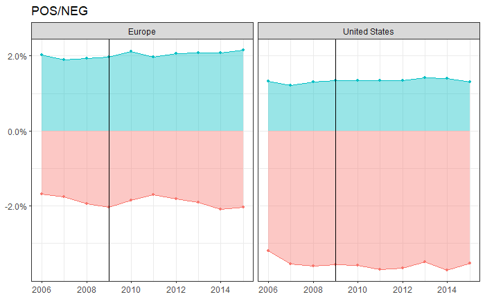

```r
show_sentiment(tab_1gram, "pos/neg")
```

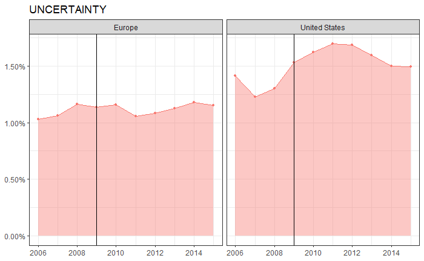

```r
show_sentiment(tab_1gram, "uncertainty")
```

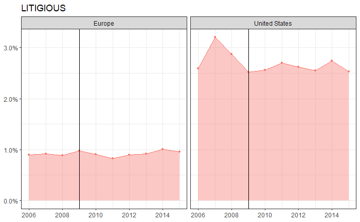

```r
show_sentiment(tab_1gram, "litigious")
```

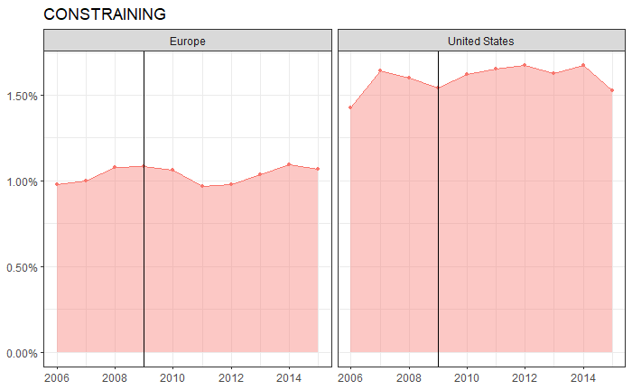

```r
show_sentiment(tab_1gram, "constraining")
```

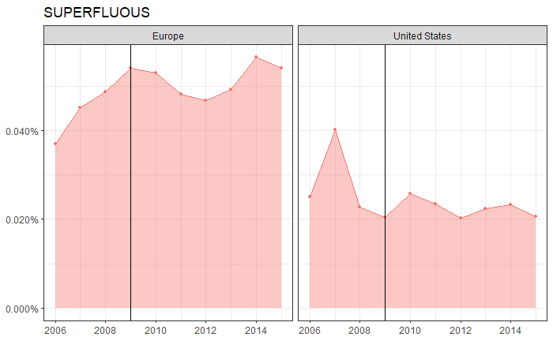

```r
show_sentiment(tab_1gram, "superfluous")
```

In the next step we move to a more insightful analysis and compare the word frequencies for unigrams and bygrams between the two jurisdictions.

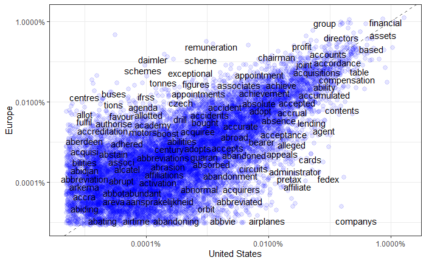

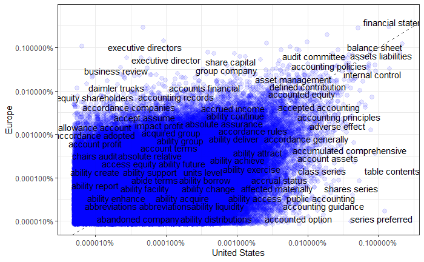

We can see that in in our setting US and European firms have relatively comparable frequencies for most words and bigrams. This is to be expected since we downloaded only high-market cap firms across all industries, hence might not have sufficient variation in underlying business models. We will try to gain some more insight in the textual differences between US and European firms by applying topic modeling algorithms

```r
if (!file.exists(lst_paths$path_lda)) {
  set.seed(123)
  tmp <- distinct(tab_files, country, company) %>%
    group_by(country) %>%
    slice_sample(n = 5) %>%
    ungroup()
  tmp <- filter(tab_files, company %in% tmp$company)
  tab <- filter(tab_1gram, doc_id %in% tmp$doc_id)

  dtm <- cast_dtm(tab, doc_id, word, n)
  lda <- LDA(dtm, k = 10, control = list(seed = 1234))
  write_rds(lda, lst_paths$path_lda)
} else {
  lda <- read_rds(lst_paths$path_lda)
}
```

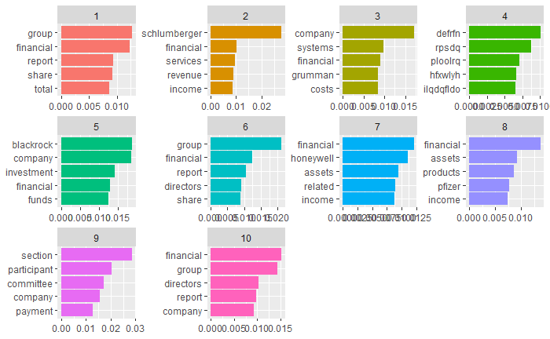

[figure not shown]

```r
chapters_gamma <- tidy(chapters_lda, matrix = "gamma")
chapters_gamma
```

```r
chapters_gamma %>%
  left_join(tab_data, by = c("document" = "doc_id")) %>%
  mutate(year = reorder(year, gamma * topic)) %>%
  ggplot(aes(factor(topic), gamma)) +
  geom_boxplot() +
  facet_wrap(~ year) +
  labs(x = "topic", y = expression(gamma))
```